# Business Statistics Assessment IB94X0 2020-2021 #1

2095515

24/1/2021

```r
salesdata <- read_csv("sales_data.csv")
salesdata
```

```
## # A tibble: 540 x 6
##    Outlet_ID outlettype              sales_1   sales_2 intrial staff_turnover
##    <chr>     <chr>                     <dbl>     <dbl> <lgl>            <dbl>
##  1 7cbc      community_convenience  6484255.  6439510. TRUE           0.00111
##  2 rd0E      community_convenience  7096007.  7345762. TRUE           0
##  3 fVhX      community_convenience  7823001.  7832002. TRUE           0.00468
##  4 HvIp      community_convenience 10865259. 10630492. FALSE          0
##  5 HGBE      community_convenience 10825611. 10611860. FALSE          0.00206
##  6 JI92      community_convenience 15629310. 16313749. TRUE           0.00143
##  7 DoWu      community_convenience  5577459.  5694963. TRUE           0.00148
##  8 p2SG      community_convenience  7580760.  8597156. TRUE           0
##  9 IVBl      community_convenience  5308958.  5523019. FALSE          0
## 10 CGzo      community_convenience 13089081. 13438805. TRUE           0
## # ... with 530 more rows
```

| Variable | Description |
| --- | --- |
| Outlet_ID | Outlet unique identifier |
| outlettype | Three different types of store that operate |
| sales_1 | The sales in each store for the last full reporting period prior trial |
| sales_2 | The sales in each store for the first full reporting period after trial |
| intrial | “TRUE”= in trial, “FALSE”= not in trial |
| staff_turnover | The proportion of staff working at each respective outlets that left during the period data covers |

## Data Transformation

We set ‘intrial’ and ‘outlettype’ variables as factors since we are dealing with categorical variables.

```r
salesdata$intrial <- as.factor(salesdata$intrial)
salesdata$outlettype <- as.factor(salesdata$outlettype)
```

We then add new columns each to find the sales difference between sales_2 and sales_1 in GBP, as well as for the rate of change in sales.

```r
salesdata <- mutate(salesdata, sales_diff_GBP = sales_2-sales_1, sales_diff_percentage = (sales_2-sales_1)*100/sales_1)
summary(salesdata)
```

```
##   Outlet_ID                           outlettype     sales_1            sales_2          intrial
##  Length:540         city_centre_convenience:162   Min.   :  344384   Min.   :  354421   FALSE:277
##  Class :character   community_convenience  :270   1st Qu.: 6306210   1st Qu.: 6304418   TRUE :263
##  Mode  :character   superstore             :108   Median :10550795   Median :10734004
##                                                   Mean   :14144900   Mean   :14362091
##                                                   3rd Qu.:16183690   3rd Qu.:16207557
##                                                   Max.   :65959576   Max.   :67704964
##  staff_turnover     sales_diff_GBP     sales_diff_percentage
##  Min.   :0.000000   Min.   :-3679574   Min.   :-12.3348
##  1st Qu.:0.000000   1st Qu.: -209595   1st Qu.: -2.3919
##  Median :0.001232   Median :   76276   Median :  0.7609
##  Mean   :0.001993   Mean   :  217191   Mean   :  0.7417
##  3rd Qu.:0.002508   3rd Qu.:  461539   3rd Qu.:  4.0820
##  Max.   :0.039476   Max.   : 6767906   Max.   : 13.5719
```

```r
salesdata %>% group_by(intrial) %>% summarise(frequency=n(), mean_sales1=mean(sales_1), mean_sales2=mean(sales_2))
```

```
## # A tibble: 2 x 4
##   intrial frequency mean_sales1 mean_sales2
##   <fct>       <int>       <dbl>       <dbl>
## 1 FALSE         277   13874491.   13892579.
## 2 TRUE          263   14429703.   14856596.
```

```r
salesdata %>% group_by(intrial) %>% summarise(frequency=n(), mean_diff_GBP=mean(sales_diff_GBP), mean_diff_percentage=mean(sales_diff_percentage))
```

```
## # A tibble: 2 x 4
##   intrial frequency mean_diff_GBP mean_diff_percentage
##   <fct>       <int>         <dbl>                <dbl>
## 1 FALSE         277        18089.                0.102
## 2 TRUE          263       426893.                1.42
```

## Question 1: Section 1

A large retailer conducted a trial of a new store layout and signage design. The trial was implemented at random to approximately half of stores under their management. These stores consist of three outlet types. These are: city centre convenience, community convenience and superstore.

Stores that were selected at random to implement the new layout and design were represented as `TRUE`, otherwise the stores are represented as `FALSE`.

To measure the impact of redesigning (`intrial: TRUE or FALSE`), we performed two measurement. We first represent the sales difference in GBP and followed by representing them in terms of percentage (%).

For sales difference in GBP, the average sales in stores that did the redesign is GBP 426,892.81 95% CI [327304-526482]. The average in that did not perform the redesign is GBP 18,088.69 95% CI [-78951-115128]. This means that stores that did the redesign, had an increase of GBP 408,804, 95% CI [269755-547853]. This increase is significant $t(483) = 5.73$, $p<0.0001$.

Similarly, for sales difference in percentage, the average sales in stores with redesign is 1.42% 95% CI[0.85-2.0] percent. The average sales in non-redesign stores is 0.10% 95% CI [-0.4-0.7] percent. Therefore, stores that did the redesign gain an increase of 1.32% 95% CI [0.5-2.1] average sales more than stores that did not perform the redesign. This is also a significant increase $t(487)=3.25$, $p=0.001$.

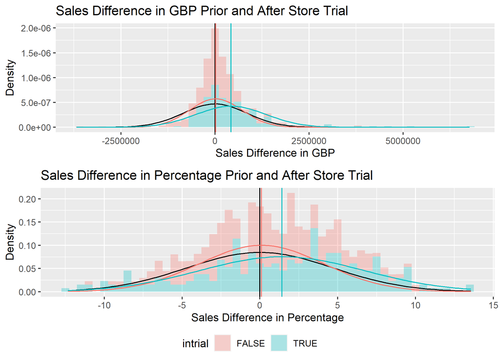

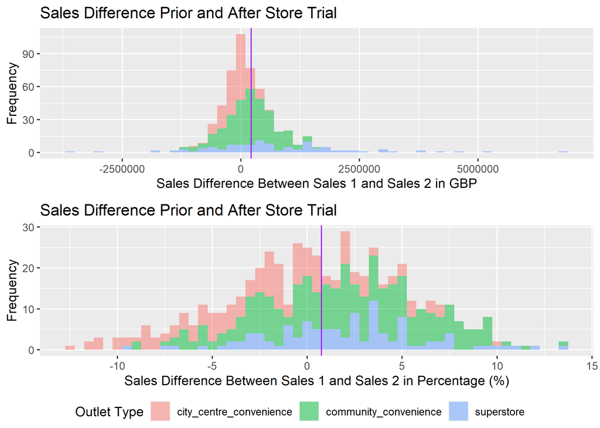

Figure 2

## Question 2: Section 1

Since we have decided to represent our result in percentage (%), we now consider controlling for outlets in trial `intrial` and their outlet type `outlettype`. We can identify see whether this model had any impact on the sales difference in percentage measures.

In the contrary, if stores were redesign (TRUE intrial) there are different effects for different types of stores. The figure also shows that, community convenience stores and superstore stores that did the redesign shows a significant increase in sales difference in percentage of 3.66% 95% CI[3.00-4.32] and 3.73% 95% CI[2.69-4.78] respectively. Unfortunately, the same cannot be said for city centre convenience store which shows a significant decrease in sales difference in percentage by 4.47% 95% CI[-5.387–3.586]. This can also be illustrated in Figure 3:

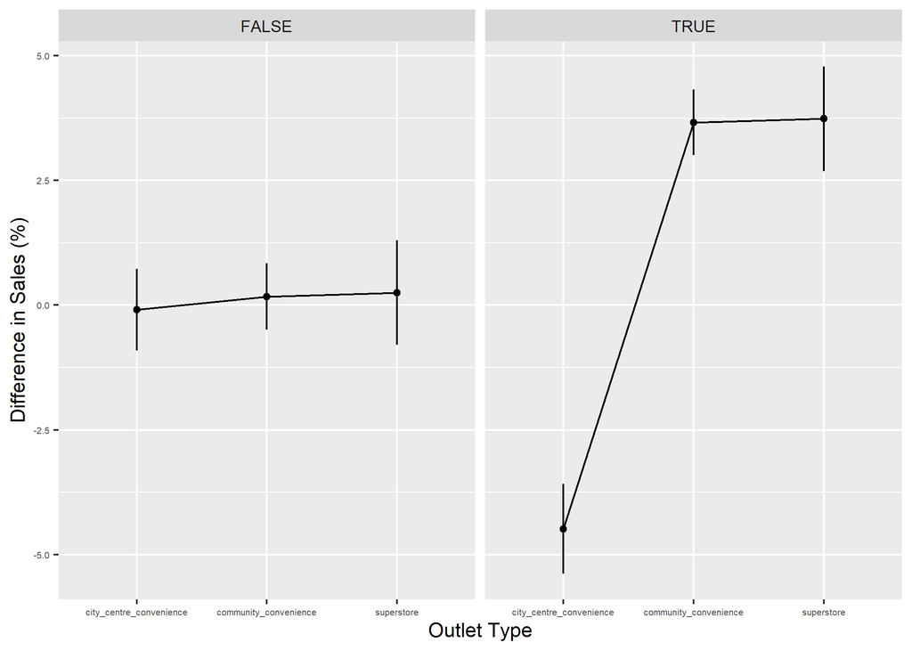

Figure 3

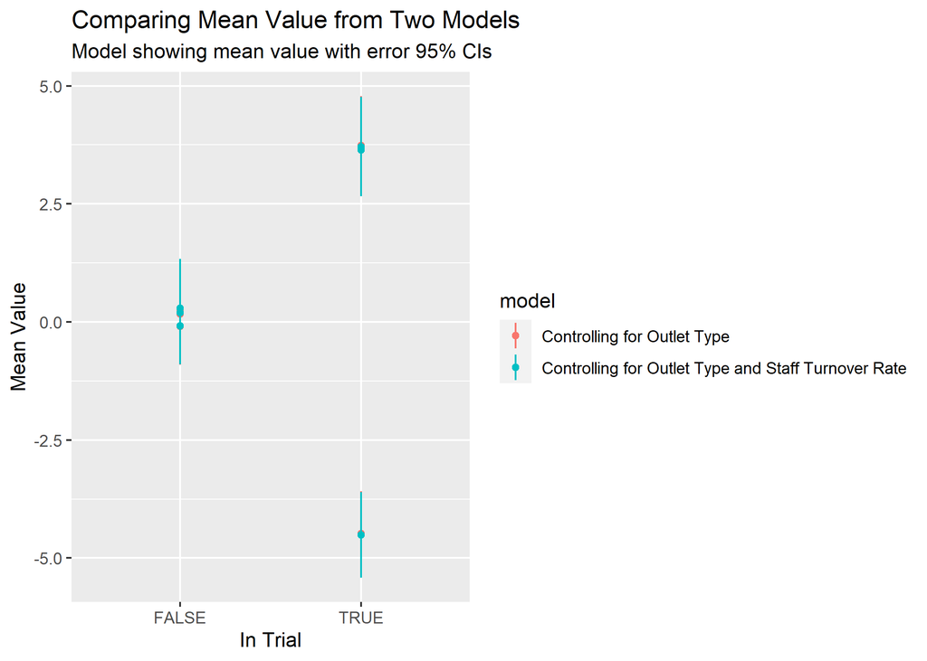

Figure 4

## Question 1: Section 2

### Sales Difference in GBP

#### Plotting The Histogram

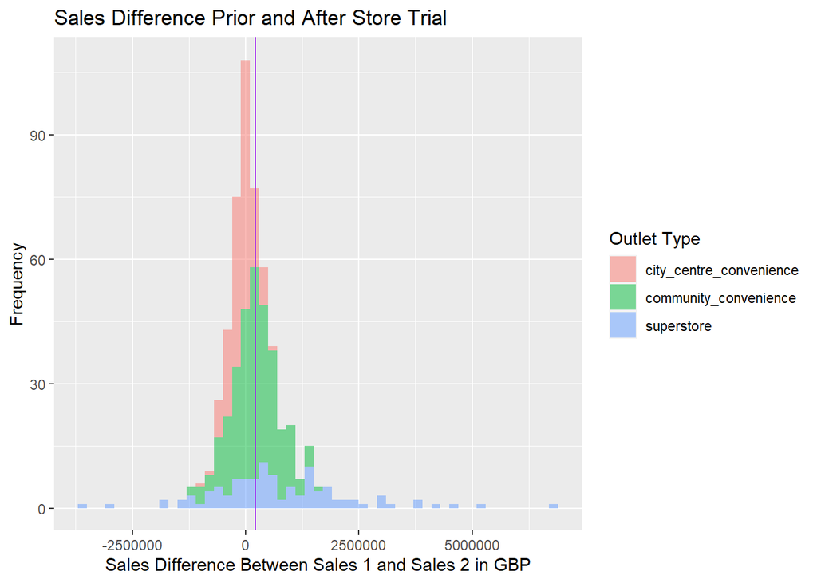

```r
othistogram_GBP<-ggplot(salesdata, aes(x=sales_diff_GBP, fill=outlettype)) + geom_histogram(binwidth = 200000, alpha=0.5) + labs(x="Sales Difference Between Sales 1 and Sales 2 in GBP", y="Frequency", fill="Outlet Type", title = "Sales Difference Prior and After Store Trial") + geom_vline(data = salesdata, mapping = aes(xintercept = mean(sales_diff_GBP)), col="purple")
othistogram_GBP
```

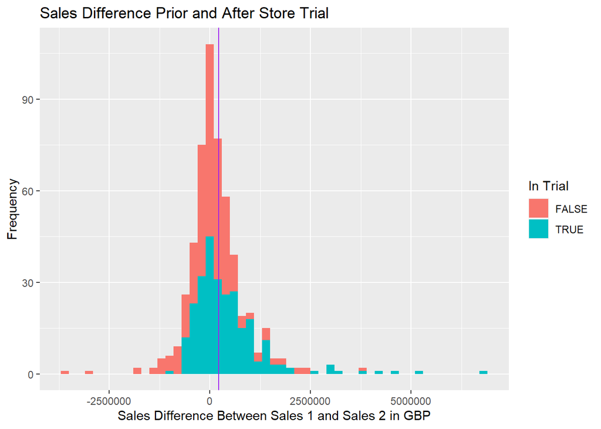

```r
ggplot(salesdata, aes(x=sales_diff_GBP, fill=intrial)) + geom_histogram(binwidth = 200000) + labs(x="Sales Difference Between Sales 1 and Sales 2 in GBP", y="Frequency", fill="In Trial", title = "Sales Difference Prior and After Store Trial") + geom_vline(data = salesdata, mapping = aes(xintercept = mean(sales_diff_GBP)), col="purple")
```

```r
sales_summary_GBP<- salesdata %>% group_by(intrial) %>% summarise(frequency=n(),mean_diff_GBP=mean(sales_diff_GBP),sd_diff_GBP=sd(sales_diff_GBP))
sales_summary_GBP
```

```
## # A tibble: 2 x 4
##   intrial frequency mean_diff_GBP sd_diff_GBP
##   <fct>       <int>         <dbl>       <dbl>
## 1 FALSE         277        18089.     695696.
## 2 TRUE          263       426893.     937123.
```

```r
sales_summary1<- salesdata %>% summarise(mean_diff_GBP=mean(sales_diff_GBP),sd_diff_GBP=sd(sales_diff_GBP))
sales_summary1
```

```
## # A tibble: 1 x 2
##   mean_diff_GBP sd_diff_GBP
##           <dbl>       <dbl>
## 1       217191.     846489.
```

```r
sales_summary_mean1<- sales_summary1$mean_diff_GBP
sales_summary_sd1<- sales_summary1$sd_diff_GBP
sales_summary_mean_false1<- as.numeric(toString(sales_summary_GBP[1,3]))
sales_summary_mean_true1<- as.numeric(toString(sales_summary_GBP[2,3]))
sales_summary_sd_false1<-as.numeric(toString(sales_summary_GBP[1,4]))
sales_summary_sd_true1<-as.numeric(toString(sales_summary_GBP[2,4]))
```

#### The Likelihood

- Null hypothesis: All of the data come from one common distribution (black line)
- Alternative hypothesis: The ‘FALSE’ (red line) data comes from a different population from ‘TRUE’ (blue line).

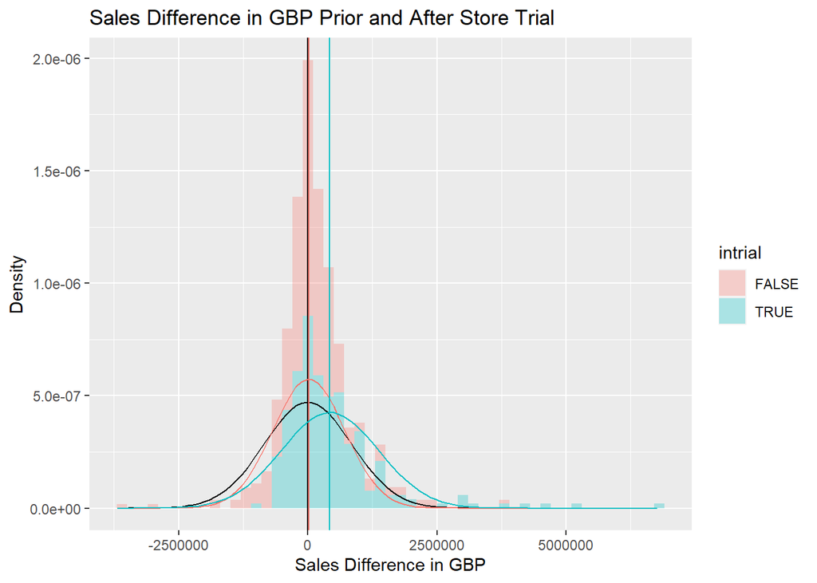

```r
colours <- scales::hue_pal()(2)
histogram_GBP<-ggplot(salesdata)+geom_histogram(aes(x=sales_diff_GBP, y=..density..,fill=intrial), binwidth = 200000, alpha=0.3)+
  stat_function(fun=function(x) {dnorm(x, mean=0, sd=sales_summary_sd1)})+
  geom_vline(data=salesdata, mapping = aes(xintercept=0))+
  stat_function(fun=function(x) {dnorm(x, mean=sales_summary_mean_false1, sd=sales_summary_sd_false1)}, col=colours[1])+
  geom_vline(data=salesdata, mapping=aes(xintercept=sales_summary_mean_false1), col=colours[1])+
  stat_function(fun=function(x) {dnorm(x, mean=sales_summary_mean_true1, sd=sales_summary_sd_true1)}, col=colours[2])+
   geom_vline(data=salesdata, mapping=aes(xintercept=sales_summary_mean_true1), col=colours[2])+ labs(x="Sales Difference in GBP", y="Density", title="Sales Difference in GBP Prior and After Store Trial")
histogram_GBP
```

From the above, we deduce that the data comes from two different population and there are two distributions. We reject the null-hypothesis. Thus, it is worth adding the extra complexity of assuming separate means and doing the trial.

#### The Boxplot

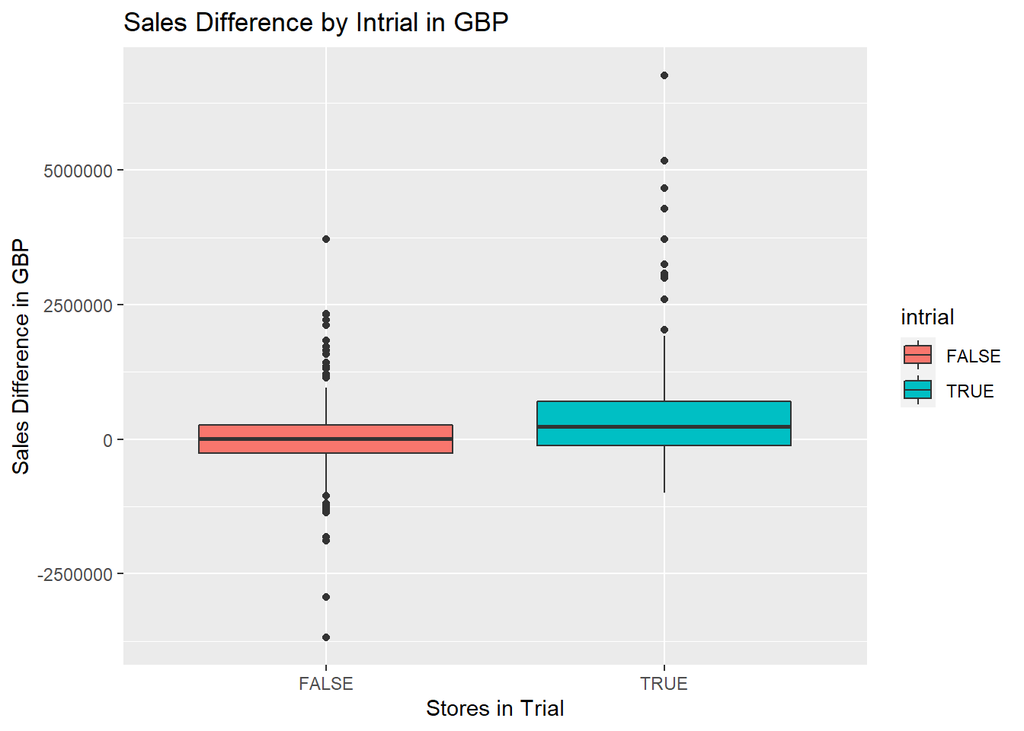

```r
GBP_boxplot<-ggplot(data = salesdata, aes(x = intrial, y = sales_diff_GBP, fill=intrial)) +
  geom_boxplot() +
  labs(y = "Sales Difference in GBP", x = "Stores in Trial", title = "Sales Difference by Intrial in GBP")
GBP_boxplot
```

#### The $t$ statistic

We run $t$-tests to see if store intrial TRUE and FALSE have different average. The intuition for $t$

$t$ will be big when:

- The difference between the sample mean and our null hypothesis population mean is big
- The standard error of the mean is small
  - The standard deviation of the sample is small
  - The sample size is large

##### $t$-test for Sales difference in GBP

```r
t.test(salesdata$sales_diff_GBP, data=salesdata)
```

```
##
##  One Sample t-test
##
## data:  salesdata$sales_diff_GBP
## t = 5.9624, df = 539, p-value = 4.499e-09
## alternative hypothesis: true mean is not equal to 0
## 95 percent confidence interval:
##  145635.0 288747.9
## sample estimates:
## mean of x
##  217191.4
```

From the above, we can deduce that there is a significant mean for retail sales of GBP 21,7191.40, $t(539) = 5.9624$, $p<.0001$.

##### $t$-test for Sales difference in GBP & intrial

This tells R to split Sales Difference in GBP by the store classification of being in trial or not. It then compare the two groups.

```r
t.test(sales_diff_GBP~intrial, data=salesdata)
```

```
##
##  Welch Two Sample t-test
##
## data:  sales_diff_GBP by intrial
## t = -5.732, df = 482.51, p-value = 1.751e-08
## alternative hypothesis: true difference in means is not equal to 0
## 95 percent confidence interval:
##  -548938.7 -268669.5
## sample estimates:
## mean in group FALSE  mean in group TRUE
##            18088.69           426892.81
```

NHST Approach: The mean retail sales in TRUE intrial is GBP 426,892.81. Whereas the mean retail sales in FALSE intrial is GBP18,088.69. Stores that did the redesign (intrial=TRUE) gain a significant GBP 408,804.12 sales more than stores that did not perform the redesign, Welch $t(483)=5.732$, $p<.0001$.

### Model: Sales Difference in GBP by In Trial

#### The NHSTesting Approach

```r
m1<-lm(sales_diff_GBP~intrial, data = salesdata)
summary(m1)
```

```
##
## Call:
## lm(formula = sales_diff_GBP ~ intrial, data = salesdata)
##
## Residuals:
##      Min       1Q   Median       3Q      Max
## -3697663  -466616   -59568   268684  6341014
##
## Coefficients:
##             Estimate Std. Error t value Pr(>|t|)
## (Intercept)    18089      49400   0.366    0.714
## intrialTRUE   408804      70785   5.775  1.3e-08 ***
## ---
## Signif. codes:  0 '***' 0.001 '**' 0.01 '*' 0.05 '.' 0.1 ' ' 1
##
## Residual standard error: 822200 on 538 degrees of freedom
## Multiple R-squared:  0.05838,    Adjusted R-squared:  0.05663
## F-statistic: 33.35 on 1 and 538 DF,  p-value: 1.3e-08
```

```r
anova (m1)
```

```
## Analysis of Variance Table
##
## Response: sales_diff_GBP
##            Df     Sum Sq    Mean Sq F value  Pr(>F)
## intrial     1 2.2546e+13 2.2546e+13  33.354 1.3e-08 ***
## Residuals 538 3.6367e+14 6.7597e+11
## ---
## Signif. codes:  0 '***' 0.001 '**' 0.01 '*' 0.05 '.' 0.1 ' ' 1
```

```r
cbind(coef(m1), confint(m1))
```

```
##                           2.5 %   97.5 %
## (Intercept)  18088.69 -78950.96 115128.3
## intrialTRUE 408804.12 269755.00 547853.2
```

For every extra store that perform the redesign there is an increase in sales difference by GBP 40,8804.00, 95% CI[269,755.00-547,853.20]. This increase is significant $t(538)=5.775$, $p<.0001$.

#### The Estimation Approach

```r
(m1_emm<- emmeans(m1,~intrial))
```

```
##  intrial emmean    SE  df lower.CL upper.CL
##  FALSE    18089 49400 538   -78951   115128
##  TRUE    426893 50697 538   327304   526482
##
## Confidence level used: 0.95
```

#### Contrasts

```r
(m1_contrast<- confint(pairs(m1_emm)))
```

```
##  contrast     estimate    SE  df lower.CL upper.CL
##  FALSE - TRUE  -408804 70785 538  -547853  -269755
##
## Confidence level used: 0.95
```

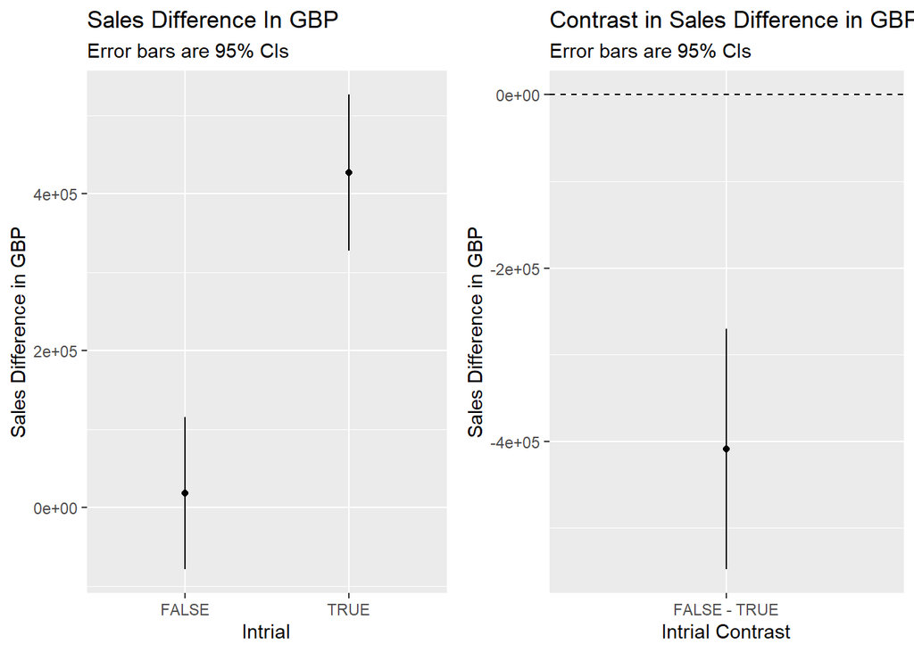

```r
grid.arrange(
  ggplot(summary(m1_emm), aes(x=intrial, y=emmean, ymin=lower.CL, ymax=upper.CL)) +
    geom_point() + geom_linerange() +
    labs(y="Sales Difference in GBP", x="Intrial", subtitle = "Error bars are 95% CIs", title="Sales Difference In GBP"),
    ggplot(m1_contrast, aes(x=contrast, y=estimate, ymin=lower.CL, ymax=upper.CL)) +
    geom_point() + geom_linerange() +
  labs(y="Sales Difference in GBP", x="Intrial Contrast", subtitle = "Error bars are 95% CIs", title="Contrast in Sales Difference in GBP") +
    geom_hline(yintercept=0, lty=2), ncol=2
)
```

Estimation Approach: The mean sales difference for TRUE intrial is GBP 426,893, 95% CI[327304-526482]. The mean sales difference for FALSE intrial is GBP 18,089, 95% CI [-78951-115128]. This means that stores that did the redesign, had an increase of GBP 408,804, 95% CI [-547853–269755]. This increase is significant $t(538)=5.775$, $p<.0001$.

### Sales Difference in Percentage (%)

#### Plotting The Histogram

```r
sales_summary<- salesdata %>% group_by(intrial) %>% summarise(frequency=n(),mean_diff_percentage=mean(sales_diff_percentage),sd_diff_percentage=sd(sales_diff_percentage))
sales_summary
```

```
## # A tibble: 2 x 4
##   intrial frequency mean_diff_percentage sd_diff_percentage
##   <fct>       <int>                <dbl>              <dbl>
## 1 FALSE         277                0.102               3.99
## 2 TRUE          263                1.42                5.29
```

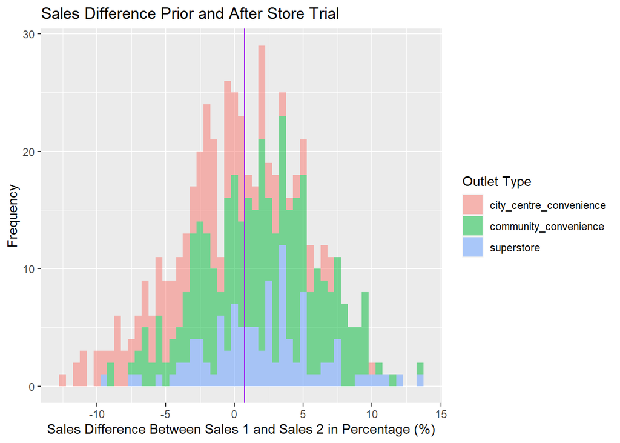

```r
othistogram_p<-ggplot(salesdata, aes(x=sales_diff_percentage, fill=outlettype)) + geom_histogram(binwidth = 0.5, alpha=0.5) + labs(x="Sales Difference Between Sales 1 and Sales 2 in Percentage (%)", y="Frequency", fill="Outlet Type", title = "Sales Difference Prior and After Store Trial") + geom_vline(data = salesdata, mapping = aes(xintercept = mean(sales_diff_percentage)), col="purple")
othistogram_p
```

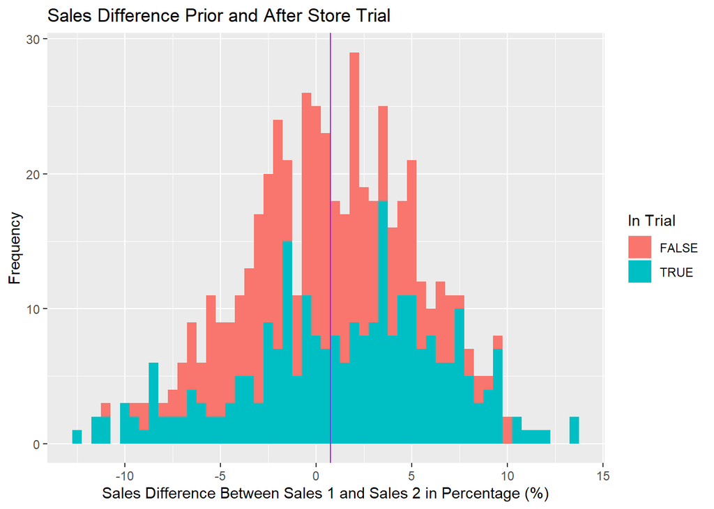

```r
ggplot(salesdata, aes(x=sales_diff_percentage, fill=intrial)) + geom_histogram(binwidth = 0.5) + labs(x="Sales Difference Between Sales 1 and Sales 2 in Percentage (%)", y="Frequency", fill="In Trial", title = "Sales Difference Prior and After Store Trial") + geom_vline(data = salesdata, mapping = aes(xintercept = mean(sales_diff_percentage)), col="purple")
```

```r
sales_summary_1<- salesdata %>% summarise(mean_diff_percentage=mean(sales_diff_percentage),sd_diff_percentage=sd(sales_diff_percentage))
sales_summary_1
```

```
## # A tibble: 1 x 2
##   mean_diff_percentage sd_diff_percentage
##                  <dbl>              <dbl>
## 1                0.742               4.71
```

```r
sales_summary_mean<- sales_summary_1$mean_diff_percentage
sales_summary_sd<- sales_summary_1$sd_diff_percentage
sales_summary_mean_false<- as.numeric(toString(sales_summary[1,3]))
sales_summary_mean_true<- as.numeric(toString(sales_summary[2,3]))
sales_summary_sd_false<-as.numeric(toString(sales_summary[1,4]))
sales_summary_sd_true<-as.numeric(toString(sales_summary[2,4]))
```

#### The Likelihood

- Null hypothesis: All of the data come from one common distribution (black line)
- Alternative hypothesis: The ‘FALSE’ (red line) data comes from a different population from ‘TRUE’ (blue line).

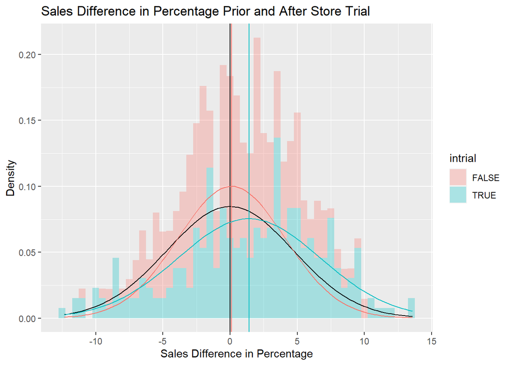

```r
colours <- scales::hue_pal()(2)
histogram_percentage<-ggplot(salesdata)+geom_histogram(aes(x=sales_diff_percentage, y=..density..,fill=intrial), binwidth = 0.5, alpha=0.3)+
  stat_function(fun=function(x) {dnorm(x, mean=0, sd=sales_summary_sd)})+
  geom_vline(data=salesdata, mapping = aes(xintercept=0))+
  stat_function(fun=function(x) {dnorm(x, mean=sales_summary_mean_false, sd=sales_summary_sd_false)}, col=colours[1])+
  geom_vline(data=salesdata, mapping=aes(xintercept=sales_summary_mean_false), col=colours[1])+
  stat_function(fun=function(x) {dnorm(x, mean=sales_summary_mean_true, sd=sales_summary_sd_true)}, col=colours[2])+
   geom_vline(data=salesdata, mapping=aes(xintercept=sales_summary_mean_true), col=colours[2])+ labs(x="Sales Difference in Percentage", y="Density", title="Sales Difference in Percentage Prior and After Store Trial")
histogram_percentage
```

From the above, we deduce that the data comes from two different population and there are two distributions. We reject the null-hypothesis. Thus, it is worth adding the extra complexity of assuming separate means and doing the trial.

#### The Boxplot

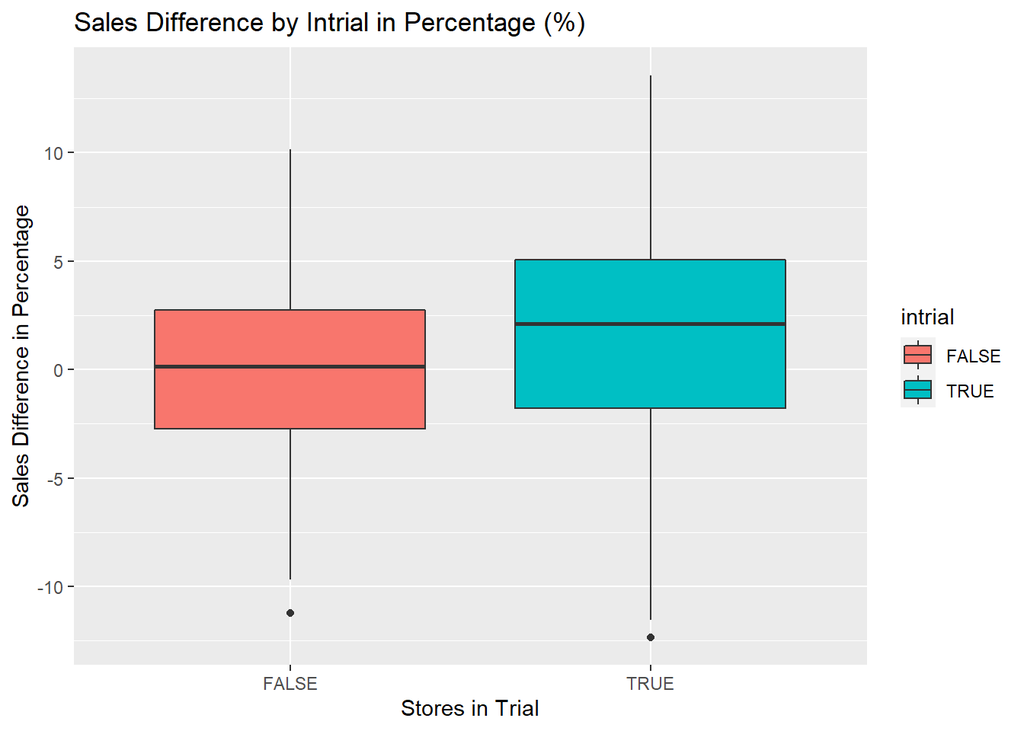

```r
percentage_boxplot<-ggplot(data = salesdata, aes(x = intrial, y = sales_diff_percentage, fill=intrial)) +
  geom_boxplot() +
  labs(y = "Sales Difference in Percentage", x = "Stores in Trial", title = "Sales Difference by Intrial in Percentage (%)")
percentage_boxplot
```

$t$ will be big when:

- The difference between the sample mean and our null hypothesis population mean is big
- The standard error of the mean is small
  - The standard deviation of the sample is small
  - The sample size is large

#####$t$-test for Sales difference in percentage (%)

```r
t.test(salesdata$sales_diff_percentage, data=salesdata)
```

```
##
##  One Sample t-test
##
## data:  salesdata$sales_diff_percentage
## t = 3.6614, df = 539, p-value = 0.0002755
## alternative hypothesis: true mean is not equal to 0
## 95 percent confidence interval:
##  0.3437786 1.1396327
## sample estimates:
## mean of x
## 0.7417057
```

From the above, we can deduce that there is a significant mean increase for retail sales of 0.74%, $t(539) = 3.6614$, $p = 0.0002755$.

##### $t$-test for Sales difference in percentage (%) & intrial

This tells R to split Sales Difference in percentage by the store classification of being in trial or not. It then compare the two groups.

```r
t.test(sales_diff_percentage~intrial, data=salesdata)
```

```
##
##  Welch Two Sample t-test
##
## data:  sales_diff_percentage by intrial
## t = -3.2472, df = 486.79, p-value = 0.001246
## alternative hypothesis: true difference in means is not equal to 0
## 95 percent confidence interval:
##  -2.1085699 -0.5187849
## sample estimates:
## mean in group FALSE  mean in group TRUE
##           0.1018961           1.4155735
```

NHST Approach: The mean retail sales in TRUE intrial is 1.42%. Whereas the mean retail sales in FALSE intrial is 0.10%. Stores that did the redesign (intrial=TRUE) gain a significant 1.32% sales more than stores that did not perform the redesign, Welch $t(487)=3.2472$, $p= 0.001246$.

### Model: Sales Difference in Percentage by In Trial

#### The NHSTesting Approach

```r
m2<-lm(sales_diff_percentage~intrial, data = salesdata)
summary(m2)
```

```
##
## Call:
## lm(formula = sales_diff_percentage ~ intrial, data = salesdata)
##
## Residuals:
##      Min       1Q   Median       3Q      Max
## -13.7504  -2.9760   0.2808   3.2649  12.1563
##
## Coefficients:
##             Estimate Std. Error t value Pr(>|t|)
## (Intercept)   0.1019     0.2803   0.363  0.71638
## intrialTRUE   1.3137     0.4017   3.270  0.00114 **
## ---
## Signif. codes:  0 '***' 0.001 '**' 0.01 '*' 0.05 '.' 0.1 ' ' 1
##
## Residual standard error: 4.666 on 538 degrees of freedom
## Multiple R-squared:  0.01949,    Adjusted R-squared:  0.01767
## F-statistic:  10.7 on 1 and 538 DF,  p-value: 0.001143
```

```r
anova (m2)
```

```
## Analysis of Variance Table
##
## Response: sales_diff_percentage
##            Df  Sum Sq Mean Sq F value   Pr(>F)
## intrial     1   232.8 232.819  10.696 0.001143 **
## Residuals 538 11710.9  21.768
## ---
## Signif. codes:  0 '***' 0.001 '**' 0.01 '*' 0.05 '.' 0.1 ' ' 1
```

```r
cbind(coef(m2), confint(m2))
```

```
##                            2.5 %    97.5 %
## (Intercept) 0.1018961 -0.4487732 0.6525654
## intrialTRUE 1.3136774  0.5246177 2.1027372
```

Indeed ‘intrial’ is a significant predictor. NHST approach: For every extra store that perform the redesign there is an increase in sales difference by 1.31%, 95% CI[0.52-2.10]. This increase is significant $t(538)=3.270$, $p=0.00114$.

#### The Estimation Approach

```r
(m2_emm<- emmeans(m2,~intrial))
```

```
##  intrial emmean    SE  df lower.CL upper.CL
##  FALSE    0.102 0.280 538   -0.449    0.653
##  TRUE     1.416 0.288 538    0.850    1.981
##
## Confidence level used: 0.95
```

#### Contrasts

```r
(m2_contrast<- confint(pairs(m2_emm)))
```

```
##  contrast     estimate    SE  df lower.CL upper.CL
##  FALSE - TRUE    -1.31 0.402 538     -2.1   -0.525
##
## Confidence level used: 0.95
```

Plotting both the CIs for the estimates for each group as well as the CI for the difference between groups.

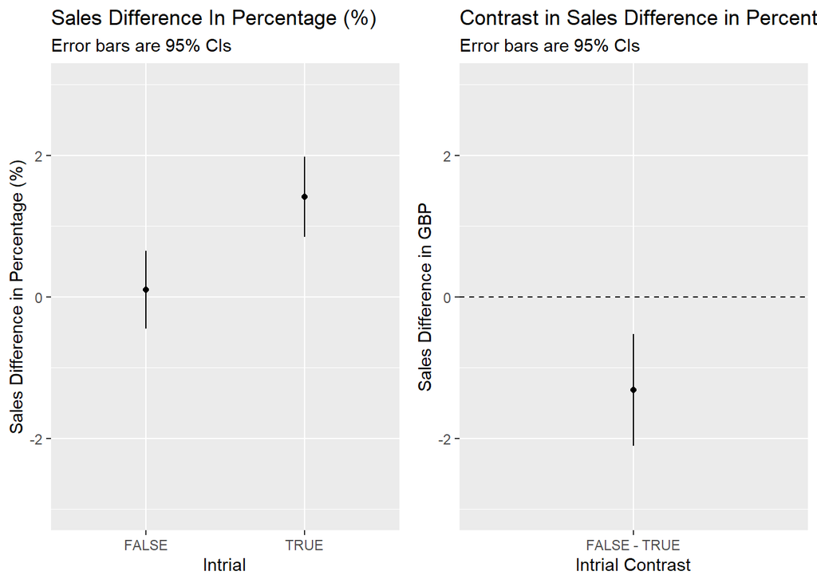

```r
grid.arrange(
  ggplot(summary(m2_emm), aes(x=intrial, y=emmean, ymin=lower.CL, ymax=upper.CL)) +
    geom_point() + geom_linerange() +
    labs(y="Sales Difference in Percentage (%)", x="Intrial", subtitle = "Error bars are 95% CIs", title="Sales Difference In Percentage (%)") + ylim(-3,3),
    ggplot(m2_contrast, aes(x=contrast, y=estimate, ymin=lower.CL, ymax=upper.CL)) +
    geom_point() + geom_linerange() +
  labs(y="Sales Difference in GBP", x="Intrial Contrast", subtitle = "Error bars are 95% CIs", title="Contrast in Sales Difference in Percentage (%)") + ylim(-3,3) +
    geom_hline(yintercept=0, lty=2), ncol=2
)
```

Estimation Approach: The mean sales difference for TRUE intrial is 1.416%, 95% CI[0.850-1.981]. The mean sales difference for FALSE intrial is 0.102%, 95% CI [-0.449-0.653]. This means that stores that did the redesign, had an increase of 1.31%, 95% CI[-2.1–0.525]. This increase is significant $t(538)=3.270$, $p=0.00114$.

#### Comparing the plots

```r
ggsave(ggarrange(histogram_GBP,histogram_percentage, nrow=2, common.legend=TRUE, legend="bottom"), file="compiled_histograms.png")
ggsave(ggarrange(othistogram_GBP,othistogram_p, nrow=2, common.legend=TRUE, legend="bottom"),file="othistogram.png")
```

## Question 2: Section 2

### Model: Sales Difference in Percentage by In Trial and Outlet Type

#### The NHSTesting Approach

```r
m3<-lm(sales_diff_percentage~intrial*outlettype, data = salesdata)
summary(m3)
```

```
##
## Call:
## lm(formula = sales_diff_percentage ~ intrial * outlettype, data = salesdata)
##
## Residuals:
##      Min       1Q   Median       3Q      Max
## -11.1389  -2.8151   0.0384   2.7384   9.9502
##
## Coefficients:
##                                             Estimate Std. Error t value Pr(>|t|)
## (Intercept)                                 -0.09247    0.41501  -0.223    0.824
## intrialTRUE                                 -4.39401    0.61824  -7.107 3.81e-12 ***
## outlettypecommunity_convenience              0.26347    0.53538   0.492    0.623
## outlettypesuperstore                         0.34323    0.67535   0.508    0.612
## intrialTRUE:outlettypecommunity_convenience  7.88545    0.78059  10.102  < 2e-16 ***
## intrialTRUE:outlettypesuperstore             7.87874    0.97466   8.084 4.23e-15 ***
## ---
## Signif. codes:  0 '***' 0.001 '**' 0.01 '*' 0.05 '.' 0.1 ' ' 1
##
## Residual standard error: 3.915 on 534 degrees of freedom
## Multiple R-squared:  0.3147, Adjusted R-squared:  0.3082
## F-statistic: 49.03 on 5 and 534 DF,  p-value: < 2.2e-16
```

```r
anova (m3)
```

```
## Analysis of Variance Table
##
## Response: sales_diff_percentage
##                     Df Sum Sq Mean Sq F value    Pr(>F)
## intrial              1  232.8  232.82  15.188 0.0001097 ***
## outlettype           2 1775.4  887.72  57.912 < 2.2e-16 ***
## intrial:outlettype   2 1749.9  874.93  57.078 < 2.2e-16 ***
## Residuals          534 8185.6   15.33
## ---
## Signif. codes:  0 '***' 0.001 '**' 0.01 '*' 0.05 '.' 0.1 ' ' 1
```

```r
#This call to anova() compares the models and tests whether the more complicated model with 'outlettype' fits significantly better
anova(m2,m3)
```

```
## Analysis of Variance Table
##
## Model 1: sales_diff_percentage ~ intrial
## Model 2: sales_diff_percentage ~ intrial * outlettype
##   Res.Df     RSS Df Sum of Sq      F    Pr(>F)
## 1    538 11710.9
## 2    534  8185.6  4    3525.3 57.495 < 2.2e-16 ***
## ---
## Signif. codes:  0 '***' 0.001 '**' 0.01 '*' 0.05 '.' 0.1 ' ' 1
```

```r
cbind(coef(m3), confint(m3))
```

```
##                                                              2.5 %     97.5 %
## (Intercept)                                 -0.09246842 -0.9077240  0.7227871
## intrialTRUE                                 -4.39400759 -5.6084861 -3.1795291
## outlettypecommunity_convenience              0.26346537 -0.7882393  1.3151700
## outlettypesuperstore                         0.34323367 -0.9834424  1.6699097
## intrialTRUE:outlettypecommunity_convenience  7.88544803  6.3520373  9.4188587
## intrialTRUE:outlettypesuperstore             7.87874431  5.9641128  9.7933758
```

NHST approach: Taking the effect of store trial into account, it can be seen that the categorical variable outlet types is significantly associated with the variation in sales difference in percentage between individual stores.

#### The Estimation Approach

```r
(m3_emm<- emmeans(m3,~intrial+outlettype))
```

```
##  intrial outlettype               emmean    SE  df lower.CL upper.CL
##  FALSE   city_centre_convenience -0.0925 0.415 534   -0.908    0.723
##  TRUE    city_centre_convenience -4.4865 0.458 534   -5.387   -3.586
##  FALSE   community_convenience    0.1710 0.338 534   -0.493    0.835
##  TRUE    community_convenience    3.6624 0.336 534    3.003    4.322
##  FALSE   superstore               0.2508 0.533 534   -0.796    1.297
##  TRUE    superstore               3.7355 0.533 534    2.689    4.782
##
## Confidence level used: 0.95
```

#### Contrasts

```r
(m3_contrast<- confint(pairs(m3_emm)))
```

```
##  contrast                                                     estimate    SE  df lower.CL upper.CL
##  FALSE city_centre_convenience - TRUE city_centre_convenience   4.3940 0.618 534     2.63     6.16
##  FALSE city_centre_convenience - FALSE community_convenience   -0.2635 0.535 534    -1.79     1.27
##  FALSE city_centre_convenience - TRUE community_convenience    -3.7549 0.534 534    -5.28    -2.23
##  FALSE city_centre_convenience - FALSE superstore              -0.3432 0.675 534    -2.27     1.59
##  FALSE city_centre_convenience - TRUE superstore               -3.8280 0.675 534    -5.76    -1.90
##  TRUE city_centre_convenience - FALSE community_convenience    -4.6575 0.570 534    -6.29    -3.03
##  TRUE city_centre_convenience - TRUE community_convenience     -8.1489 0.568 534    -9.77    -6.52
##  TRUE city_centre_convenience - FALSE superstore               -4.7372 0.703 534    -6.75    -2.73
##  TRUE city_centre_convenience - TRUE superstore                -8.2220 0.703 534   -10.23    -6.21
##  FALSE community_convenience - TRUE community_convenience      -3.4914 0.477 534    -4.85    -2.13
##  FALSE community_convenience - FALSE superstore                -0.0798 0.631 534    -1.88     1.73
##  FALSE community_convenience - TRUE superstore                 -3.5645 0.631 534    -5.37    -1.76
##  TRUE community_convenience - FALSE superstore                  3.4117 0.630 534     1.61     5.21
##  TRUE community_convenience - TRUE superstore                  -0.0731 0.630 534    -1.87     1.73
##  FALSE superstore - TRUE superstore                            -3.4847 0.753 534    -5.64    -1.33
##
## Confidence level used: 0.95
## Conf-level adjustment: tukey method for comparing a family of 6 estimates
```

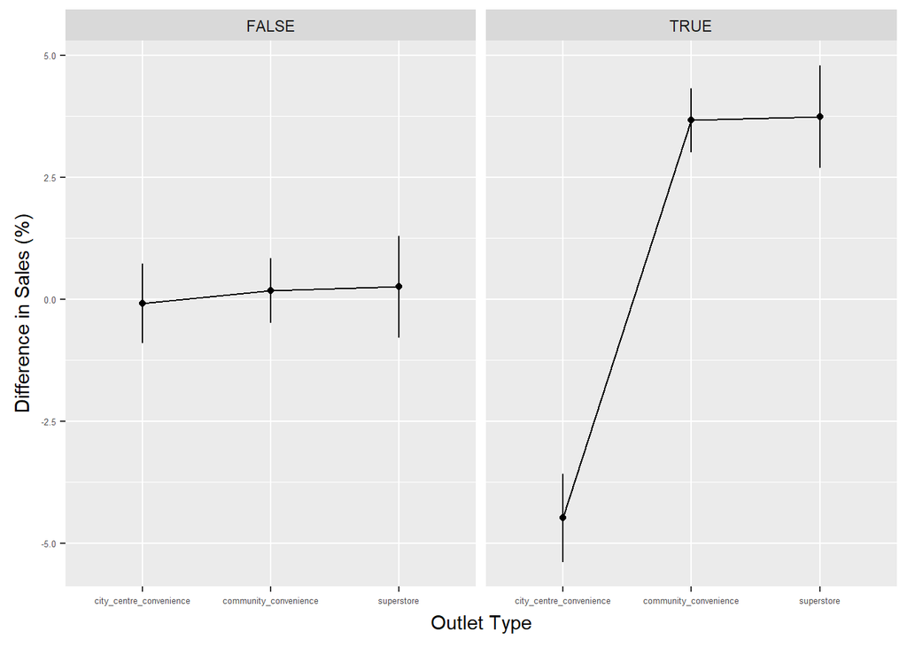

```r
ot<-ggplot(summary(m3_emm), aes(x=outlettype, y=emmean, ymin=lower.CL, ymax=upper.CL, group=intrial)) + geom_point() + geom_linerange() + labs(x="Outlet Type", y="Difference in Sales (%)") + facet_grid(.~intrial) + geom_line()+ theme(axis.text=element_text(size = 5))
ot
```

```r
ggsave(ot, file="ot.png")
```

On the other hand, it would seem that outlet type has no significant sales difference for the stores that did not sign up for the trial(`intrialFALSE`). This can also be represented by the graph below:

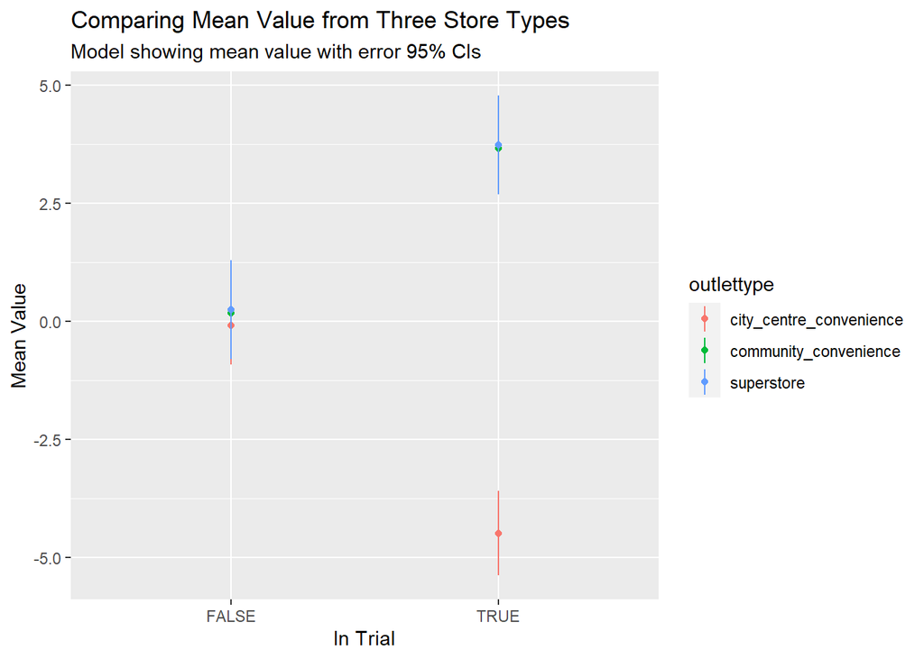

```r
m3_summary<- summary(m3_emm)

ggplot(m3_summary, aes(x=intrial, y=emmean, ymin=lower.CL, ymax=upper.CL, color=outlettype))+ geom_point()+ geom_linerange() + labs(y="Mean Value", x="In Trial", subtitle = "Model showing mean value with error 95% CIs", title= "Comparing Mean Value from Three Store Types")
```

Here we have constructed to a plot to highlight the importance of controlling for outlet type (`outlettype`).

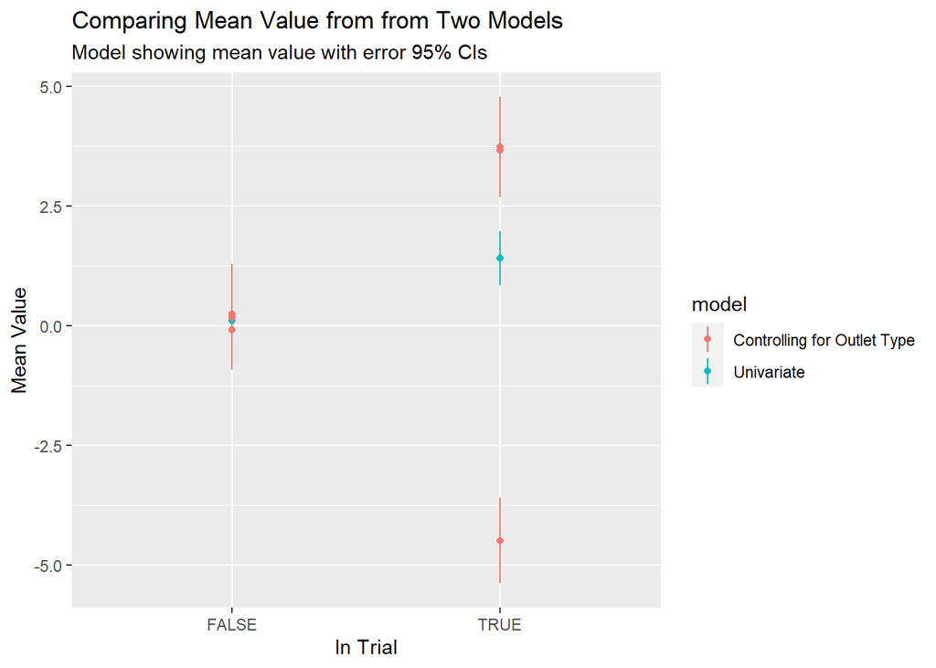

```r
both_models_emms <- bind_rows(list(data.frame(m2_emm, model="Univariate"), data.frame(m3_emm, model="Controlling for Outlet Type")))


ggplot(both_models_emms, aes(x=intrial, y=emmean, ymin=lower.CL, ymax=upper.CL, color=model))+ geom_point()+ geom_linerange() + labs(y="Mean Value", x="In Trial", subtitle = "Model showing mean value with error 95% CIs", title= "Comparing Mean Value from from Two Models")
```

Estimation Approach: if stores were redesign (TRUE intrial) there are different effects for different types of stores. The figure also shows that, community convenience stores and superstore stores that did the redesign shows a significant increase in sales difference in percentage of 3.66% 95% CI[3.00-4.32] and 3.73% 95% CI[2.69-4.78] respectively. Unfortunately, the same cannot be said for city centre convenience store which shows a significant decrease in sales difference in percentage by 4.47% 95% CI[-5.387–3.586].

### Model: Sales Difference in Percentage by In Trial and Outlet Type and Staff Turnover

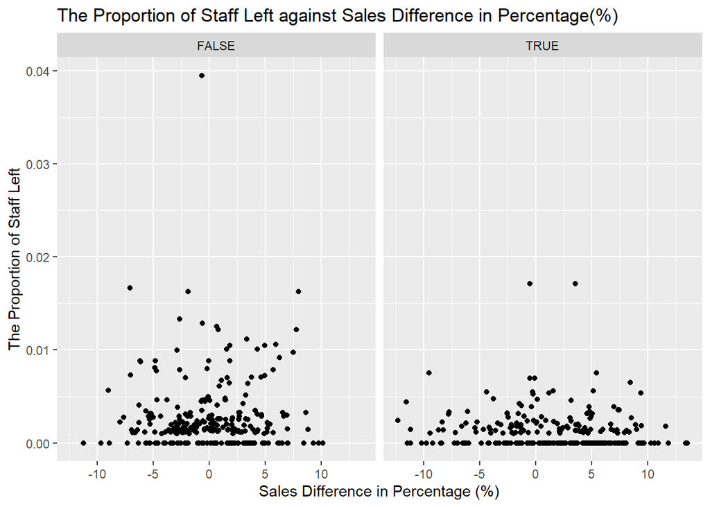

```r
ggplot(salesdata, aes(x=sales_diff_percentage, y=staff_turnover))+geom_point() + facet_grid(~intrial)+ labs(y="The Proportion of Staff Left", x="Sales Difference in Percentage (%)", title="The Proportion of Staff Left against Sales Difference in Percentage(%)")
```

#### Correlation

```r
cor(select(salesdata, staff_turnover, sales_diff_percentage))
```

```
##                       staff_turnover sales_diff_percentage
## staff_turnover            1.00000000           -0.04487586
## sales_diff_percentage    -0.04487586            1.00000000
```

#### The NHSTesting Approach

```r
m4<- lm(sales_diff_percentage~intrial*outlettype+staff_turnover, data=salesdata)
summary(m4)
```

```
##
## Call:
## lm(formula = sales_diff_percentage ~ intrial * outlettype + staff_turnover,
##     data = salesdata)
##
## Residuals:
##      Min       1Q   Median       3Q      Max
## -11.2111  -2.8109   0.0989   2.7211   9.9121
##
## Coefficients:
##                                             Estimate Std. Error t value Pr(>|t|)
## (Intercept)                                  -0.0203     0.4332  -0.047    0.963
## intrialTRUE                                  -4.4281     0.6213  -7.127 3.36e-12 ***
## outlettypecommunity_convenience               0.2763     0.5362   0.515    0.606
## outlettypesuperstore                          0.3685     0.6771   0.544    0.587
## staff_turnover                              -31.1948    53.2750  -0.586    0.558
## intrialTRUE:outlettypecommunity_convenience   7.8759     0.7812  10.081  < 2e-16 ***
## intrialTRUE:outlettypesuperstore              7.8540     0.9762   8.046 5.60e-15 ***
## ---
## Signif. codes:  0 '***' 0.001 '**' 0.01 '*' 0.05 '.' 0.1 ' ' 1
##
## Residual standard error: 3.918 on 533 degrees of freedom
## Multiple R-squared:  0.3151, Adjusted R-squared:  0.3074
## F-statistic: 40.87 on 6 and 533 DF,  p-value: < 2.2e-16
```

```r
anova(m4)
```

```
## Analysis of Variance Table
##
## Response: sales_diff_percentage
##                     Df Sum Sq Mean Sq F value    Pr(>F)
## intrial              1  232.8  232.82 15.1696 0.0001108 ***
## outlettype           2 1775.4  887.72 57.8403 < 2.2e-16 ***
## staff_turnover       1   13.2   13.19  0.8591 0.3544123
## intrial:outlettype   2 1741.9  870.97 56.7492 < 2.2e-16 ***
## Residuals          533 8180.4   15.35
## ---
## Signif. codes:  0 '***' 0.001 '**' 0.01 '*' 0.05 '.' 0.1 ' ' 1
```

```r
cbind(coef(m4), confint(m4))
```

```
##                                                                2.5 %     97.5 %
## (Intercept)                                  -0.0203026   -0.8712328  0.8306276
## intrialTRUE                                  -4.4280814   -5.6486778 -3.2074850
## outlettypecommunity_convenience               0.2763265   -0.7769145  1.3295676
## outlettypesuperstore                          0.3684774   -0.9617201  1.6986749
## staff_turnover                              -31.1947960 -135.8494679 73.4598759
## intrialTRUE:outlettypecommunity_convenience   7.8759408    6.3412477  9.4106340
## intrialTRUE:outlettypesuperstore              7.8539900    5.9363721  9.7716080
```

```r
#Comparing the models when we decide to add 'staff_turnover' predictor
anova(m3,m4)
```

```
## Analysis of Variance Table
##
## Model 1: sales_diff_percentage ~ intrial * outlettype
## Model 2: sales_diff_percentage ~ intrial * outlettype + staff_turnover
##   Res.Df    RSS Df Sum of Sq      F Pr(>F)
## 1    534 8185.6
## 2    533 8180.4  1    5.2621 0.3429 0.5584
```

#### The Estimation Approach

```r
(m4_emm<- emmeans(m4,~intrial+outlettype+staff_turnover))
```

```
##  intrial outlettype              staff_turnover  emmean    SE  df lower.CL upper.CL
##  FALSE   city_centre_convenience        0.00199 -0.0825 0.416 533   -0.899    0.734
##  TRUE    city_centre_convenience        0.00199 -4.5106 0.460 533   -5.415   -3.606
##  FALSE   community_convenience          0.00199  0.1938 0.341 533   -0.475    0.863
##  TRUE    community_convenience          0.00199  3.6417 0.338 533    2.978    4.305
##  FALSE   superstore                     0.00199  0.2860 0.537 533   -0.768    1.340
##  TRUE    superstore                     0.00199  3.7119 0.535 533    2.662    4.762
##
## Confidence level used: 0.95
```

#### Contrasts

```r
(m4_contrast<- confint(pairs(m4_emm)))
```

```
##  contrast
##  FALSE city_centre_convenience 0.00199328445185185 - TRUE city_centre_convenience 0.00199328445185185
##  FALSE city_centre_convenience 0.00199328445185185 - FALSE community_convenience 0.00199328445185185
##  FALSE city_centre_convenience 0.00199328445185185 - TRUE community_convenience 0.00199328445185185
##  FALSE city_centre_convenience 0.00199328445185185 - FALSE superstore 0.00199328445185185
##  FALSE city_centre_convenience 0.00199328445185185 - TRUE superstore 0.00199328445185185
##  TRUE city_centre_convenience 0.00199328445185185 - FALSE community_convenience 0.00199328445185185
##  TRUE city_centre_convenience 0.00199328445185185 - TRUE community_convenience 0.00199328445185185
##  TRUE city_centre_convenience 0.00199328445185185 - FALSE superstore 0.00199328445185185
##  TRUE city_centre_convenience 0.00199328445185185 - TRUE superstore 0.00199328445185185
##  FALSE community_convenience 0.00199328445185185 - TRUE community_convenience 0.00199328445185185
##  FALSE community_convenience 0.00199328445185185 - FALSE superstore 0.00199328445185185
##  FALSE community_convenience 0.00199328445185185 - TRUE superstore 0.00199328445185185
##  TRUE community_convenience 0.00199328445185185 - FALSE superstore 0.00199328445185185
##  TRUE community_convenience 0.00199328445185185 - TRUE superstore 0.00199328445185185
##  FALSE superstore 0.00199328445185185 - TRUE superstore 0.00199328445185185
##  estimate    SE  df lower.CL upper.CL
##    4.4281 0.621 533     2.65     6.21
##   -0.2763 0.536 533    -1.81     1.26
##   -3.7242 0.537 533    -5.26    -2.19
##   -0.3685 0.677 533    -2.31     1.57
##   -3.7944 0.678 533    -5.73    -1.85
##   -4.7044 0.576 533    -6.35    -3.06
##   -8.1523 0.568 533    -9.78    -6.53
##   -4.7966 0.710 533    -6.83    -2.76
##   -8.2225 0.703 533   -10.23    -6.21
##   -3.4479 0.483 533    -4.83    -2.07
##   -0.0922 0.632 533    -1.90     1.71
##   -3.5181 0.636 533    -5.34    -1.70
##    3.3557 0.637 533     1.53     5.18
##   -0.0702 0.630 533    -1.87     1.73
##   -3.4259 0.761 533    -5.60    -1.25
##
## Confidence level used: 0.95
## Conf-level adjustment: tukey method for comparing a family of 6 estimates
```

Here we have constructed to a plot to highlight the importance of adding Staff Turnover (`staff_turnover`) as a predictor:

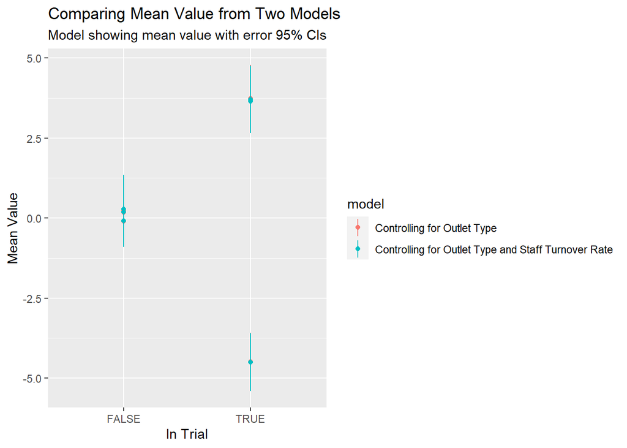

```r
both_models_emms <- bind_rows(list(data.frame(m3_emm, model="Controlling for Outlet Type"), data.frame(m4_emm, model="Controlling for Outlet Type and Staff Turnover Rate")))


staff_turnover_graph<-ggplot(both_models_emms, aes(x=intrial, y=emmean, ymin=lower.CL, ymax=upper.CL, color=model))+ geom_point()+ geom_linerange() + labs(y="Mean Value", x="In Trial", subtitle = "Model showing mean value with error 95% CIs", title= "Comparing Mean Value from Two Models")
staff_turnover_graph
```

```r
ggsave(staff_turnover_graph, file="staff_turnover.png")
```

Adding staff turnover rate to the model does not improve the fit. Superimposing the plot of the models with and without the `staff_turnover` covariate show that there is not much of a change in the estimates of the sales difference means in percentage. Thus it is not worth adding `staff_turnover` as a predictor.